# League Data Case Study

Cullen Elliott Wright

2024-07-23

# Part I: Winrate by Friendship

## “Do you win more or less with more friends?”

My partner asked me this question while we we’re discussing playing videogames. The prime question being: does the coordination provided by having people communicating together in the game increase our winrate a significantly measurable amount? Or does some other factor, such as “playing for fun,” losing focus on the game, or trying to showoff more cause the counter the supposed benefits?

## Obtaining the data

Data was collected using the API provided by Riot Games. This was achieved by writing a Python script that queries Riot’s API for match data on the games that I had played in the span of approximately a year (from April 3rd 2023 - April 24th 2024). There were 980 matches logged in this time frame, with 10 players per game, giving me 9800 observations. For each observation I retained 43 variable data points. Providing me with 421,400 data points to derive insights from.

The data collected included observations on: Player name, if the game was a win, number of kills, deaths, and assists, multikills, total time spent dead, total and team percentage of damage taken/dealt, date and time the game was played, and many more.

### Who do I play with most?

The first question we want to answer is who do I play with the most. When we filter the data set for players who appear in five or more games we get this result:

| Summoner Name | Game Count |
| --- | --- |
| SquidVicious | 980 |
| Themnem | 924 |
| Nimh | 793 |
| volcanotechie | 616 |
| mathmavin | 101 |
| Taudd | 44 |
| GingerJones17 | 22 |
| JHenson | 5 |

The filter for five or more games was chosen because it ensures we are only capturing data points from players that were specifically queued with. There were several unknown players who appeared fewer than five times but more than once. We notice this phenomenom that a player from the previous game appears in the subsequent game as well.

After determining the player’s names that meet our playcount criteria, We subdivided that data further. One dataset that contains all of the aforementioned players, and another more strict dataset that contains only the core group of players with greater than 100 games in the sample. This was done because there are some statistical anomolies that occur in the small sample sizes of the eliminated players.

## Exploring Winrate Across Several Metrics

The first concept we explored was whether there was a correlation between the length of a game, and our win rate. By batching games into minute intervals, we can observe how winrate changes by how long a game persists.

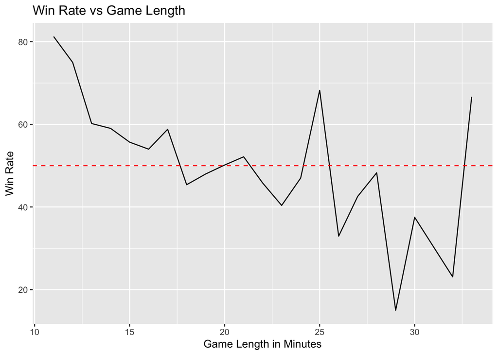

We also wanted to explore whether the time of night a game was played affects the winrate. You will notice that the “Hour” axis on this graph extends past 12 (midnight) onto 13 and 14. This is because it was more useful to combine games played after midnight with the games played before on the previous day. It was more useful to group games into “nights” than “days.” (all times are in pacific standard time)

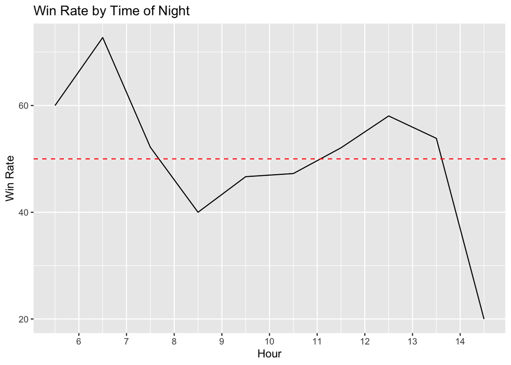

We first notice that there is an incredibly high win rate before seven thirty followed by a slump that continues until approximately 11pm. 11pm pacific time is the bedtime of one of the players in the group. Perhaps suggesting that as friends leave the call for the evening, that winrate increases. How then do we explain the drop in win rate as we approach 2am? One theory could simply be fatigue as the night goes on. Another idea that was explored was that more consecutive games causes fatigue in and of itself, and that winrate would decrease as more games are played in a single session.

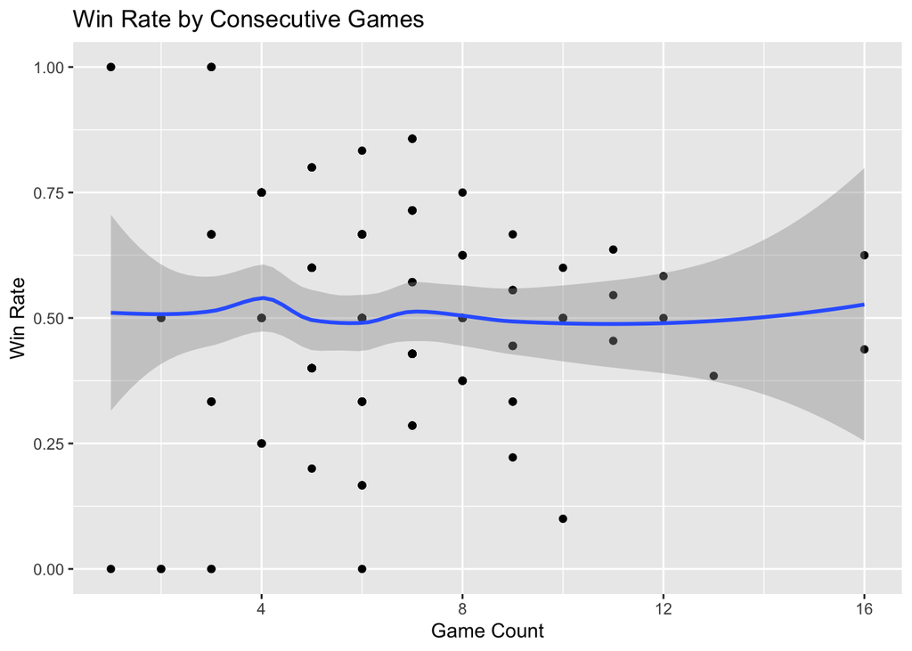

When we plot win rate against game count though, we find that there is very little correlation. Consecutive games is not an answer to increasing win rates.

Next we explored if the weekly schedules of the players would affect win rates. Our theory being that weekends and Wednesdays would be the best to play on. This is because of group availability on weekends, as well as a standing weekly game night on wednesdays that are highly attended by the group.

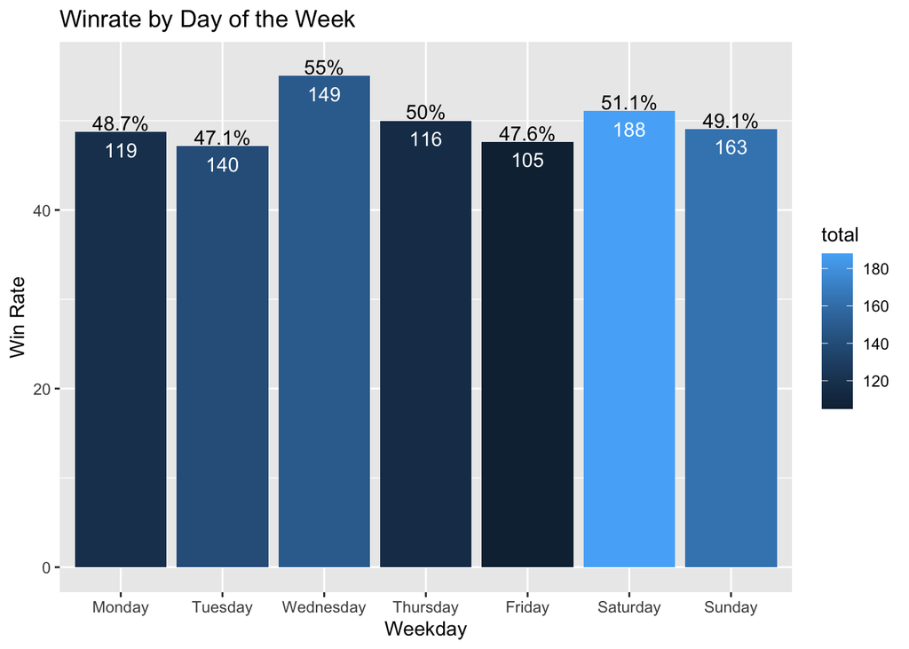

We can see that indeed Wednesdays have the highest wi nrate, and the most total games played on weekdays. Saturdays have the most games total, and second highest win rate overall. We also see that Sunday has more games than any weekday, and a higher win rate than any weekday other than Wednesday or Thursday. This makes me very confidant in the correlation between win rate and number of friends in games.

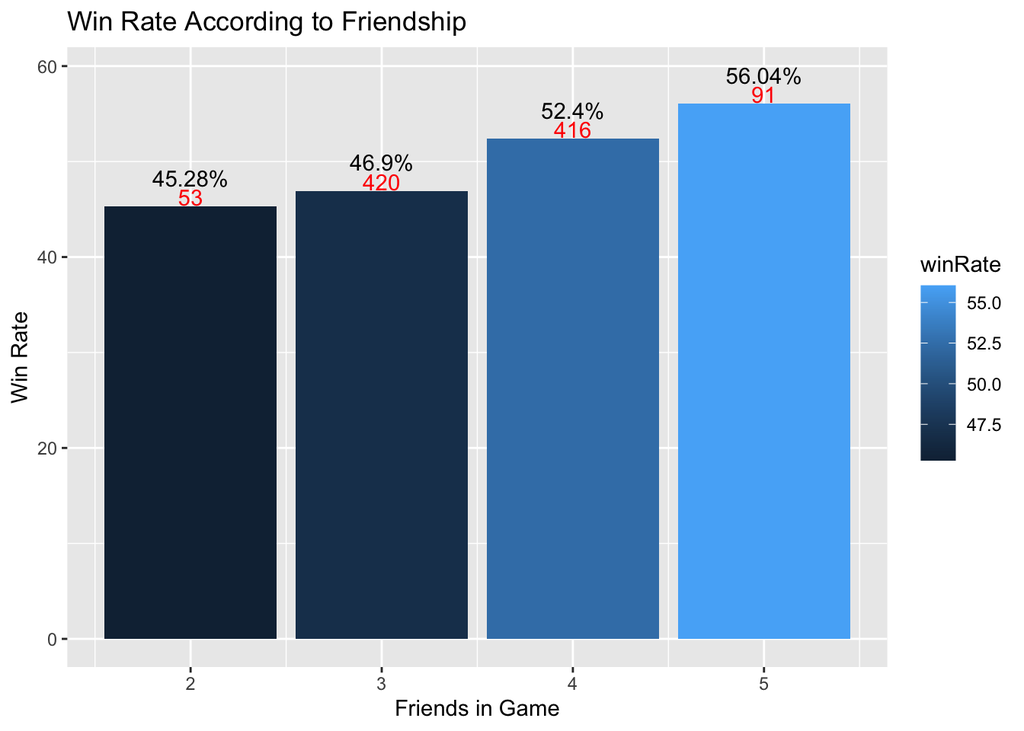

We observe here a clear link between the number of friends present in a game and the win rate. Win rate and Friend count have a correlation factor of .98, indicating a very likely link between the friend count and win rate of games.

## Conclusions

We have very confidently shown that the benefits of playing with a group, even casually, are likely to outweigh any detriments that occur from not taking the game seriously because of your friends. We have also demonstrated that there is likely a benefit from having a recurring scheduled game time that ensures that more people are able to attend.

# Part II: Dodging Skillshots

## Who Dodges The Most?

When you gather a large data set about how you and your friends play a video game, one of the most prominent uses is that you can use it to check confirmation bias of your friend groups assumptions. The most common assumption in my own friend groups playing habbits is that “volcanotechie can’t dodge skillshots.” For context, a skillshot is a non-targeted ability that must be manually aimed by the player to hit the target. The skillshot itself then has travel time to the target giving the target the ability to move out of the way or “dodge” the skillshot. Dodging skillshots is an integral part of playing League of Legends. A raw count of “skillShotsDodged” was available in the data set. When we group by player and average the amount for each game we come up with this:

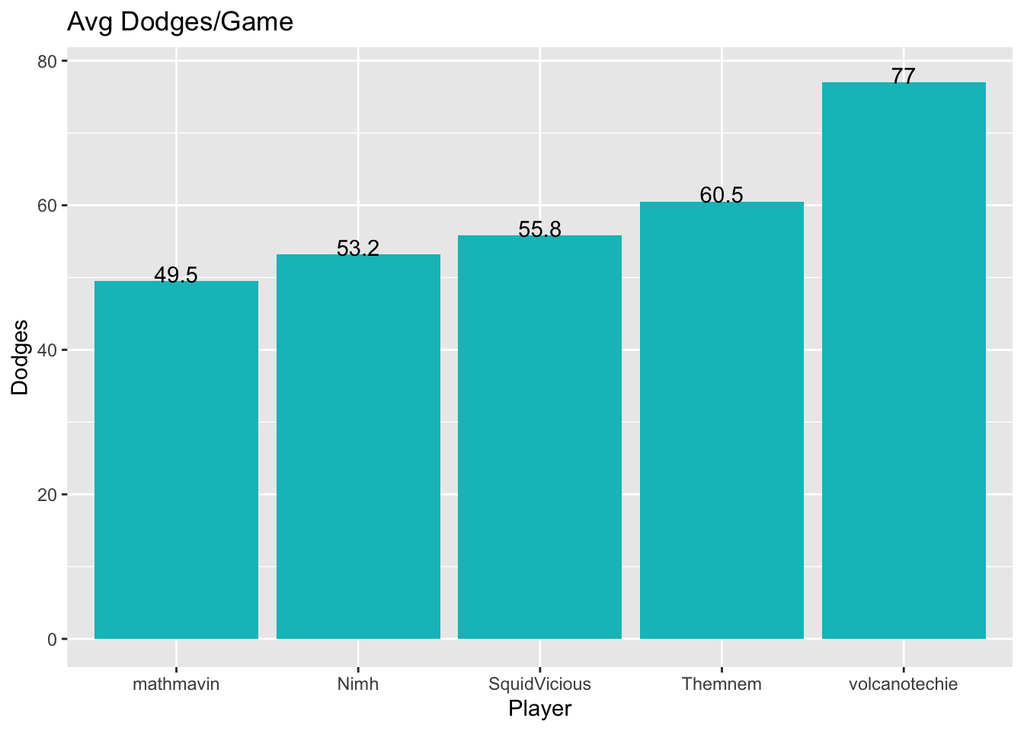

We can see that contrary to group opinion on average volcanotechie is dodging the most skillshots in the group. Nearly 30% more than the next best dodger. However with the difference being wider between first and second place than it was between second and fifth, I decided to do some more digging. if we look at the Dodge Rate of each player (that is skillshots dodged per second of game time), We can start to see where some of our anomolies are taking place.

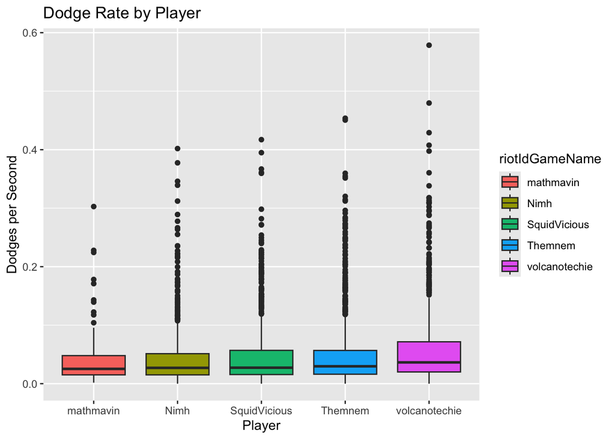

We can immediately observe that there are many outlier data points that are affecting our calculations. Having a game reporting an average dodge amount of .6 dodges per second should be near impossible and must be being affected by some unintended interactions. When we delve directly into the outlier datapoints on dodge rate we can find some similarities. All of the top dodge ratings occurred while playing champions in that have a melee attack range (that is the player must approach the enemy to attack them.) Further most of these champions seem to belong to the “tank” subclass (champions that are designed around being able to take lots of damage, and have a play style that encourages disrupting the enemy team). We also calculated a mean dodge rating throughout all games as 0.05 dodges per second, with a standard deviation of 0.059. This indeed leads me to believe that achieving .6 dodges per second (more than 9 standard deviations away from the mean) is indeed aberrant data.

## Controlling for Outliers

To control the outlier data’s effects on results, we had to come up with a couple solutions. While there was a skillshots dodged data point, there wasn’t a “hit by skillshots” count that could be used to compare. Since the data skewed for tank class characters though, I had the idea to normalize our doding on a data point that was available “percentTeamDamageTaken.” This would reward dodging skillshots on champions that have less abililty to take damage, as well as would count less for champions that may be getting dodge numbers from skillshots being targeted past them. I also controlled for any data points that were occuring outside of three standard deviations from the mean.

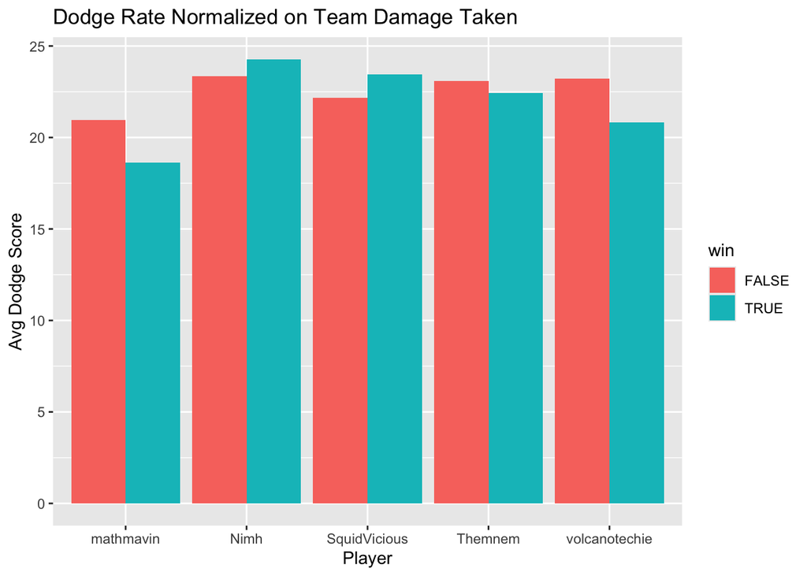

We can now see that when several factors that contributed to outlier data that the Dodge Rate of players in the group are much more alligned. We also find that volcanotechie does not dodge the fewest skillshots and that title should be attributed to mathmavin.

# Bonus Stats

Here are some other fun visualizations that were created in the course of working through this data set.

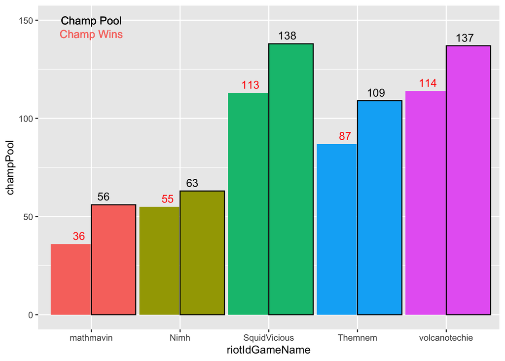

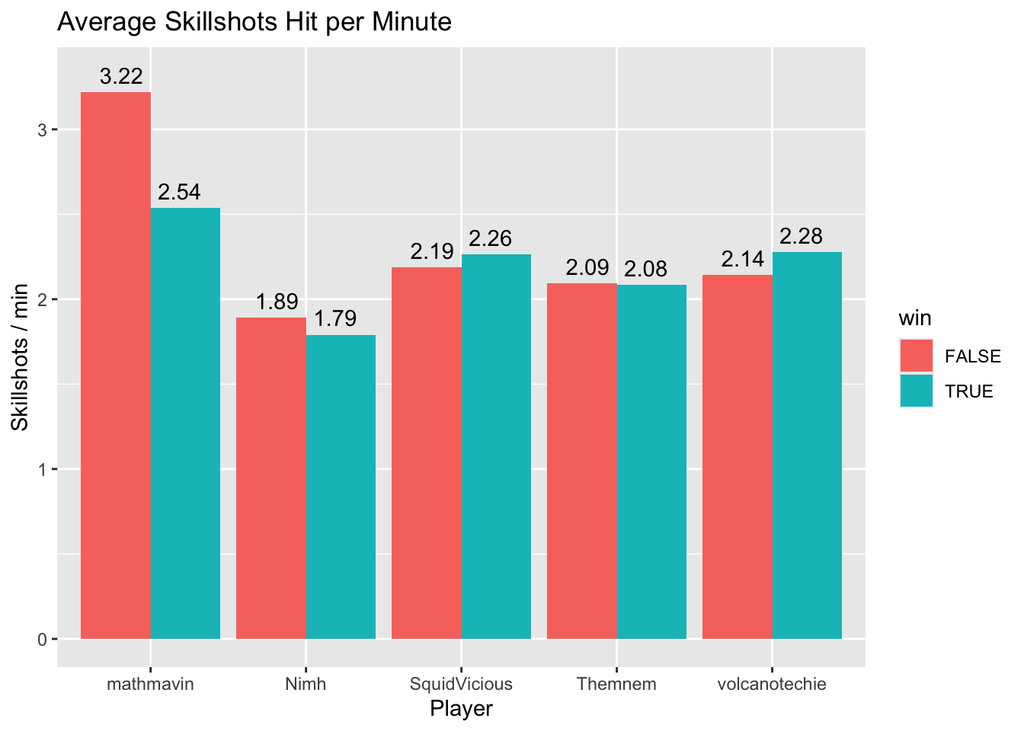

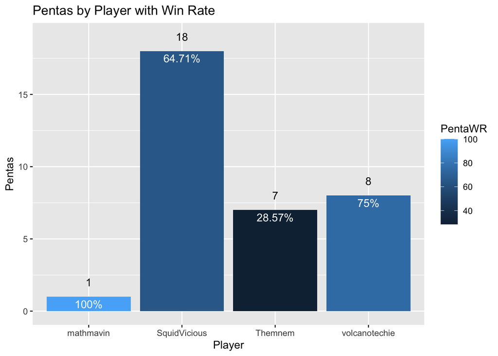

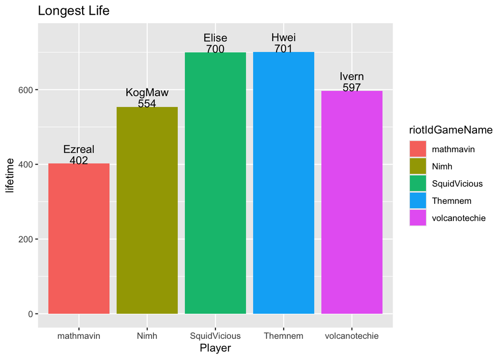

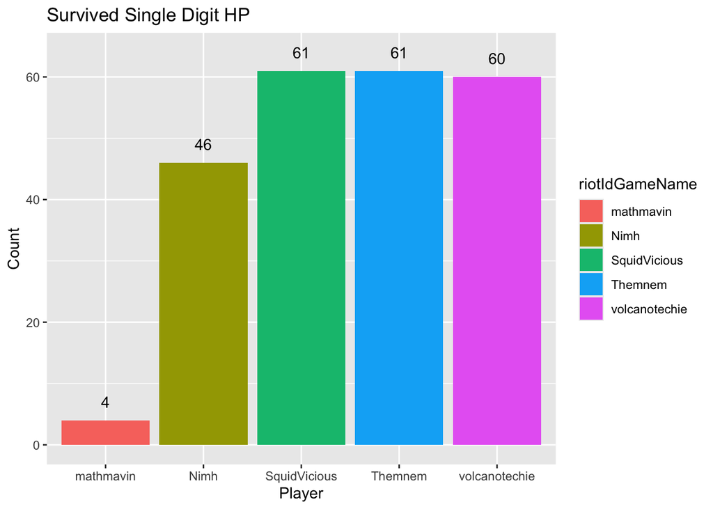